# The m-format Constellation User Manual

# `ms repair`

BCH error-correct a single `ms1` string (ms-cli v0.4.0+). Wraps `ms_codec::decode_with_correction` and renders a single-chunk repair report. The string is corrected within the `BCH(93,80,8)` `t=4` capacity (up to four substitution errors). `ms repair` is the per-codec sibling of the toolkit’s `mnemonic repair`; the two surfaces share the same `RepairJson` envelope byte-exact.

Single-HRP context: there is no `--hrp` flag and no variadic positional — an `ms1` is single-chunk by codex32 specification (HRP `ms` is always a single-string `BCH(93,80,8)` card).

> **GUI form:** see GUI Forms › ms › repair.

## Outline

- `--ms1` — the `ms1` string to repair (required; `-` reads stdin; secret-bearing)
- `--json` — emit a single JSON envelope on stdout instead of the text report

## `--ms1`

The `ms1` string to attempt to repair via BCH error correction. **Required.** A literal `-` reads the string from stdin (a single line).

**Secret-bearing** — schema-`secret: true`. The to-be-repaired `ms1` IS master-secret material: it is BCH-corrupted BIP-39 entropy, and the corrected output reconstructs the seed card. The GUI renders this as a `SecretLineEdit` widget; a non-empty value triggers the run-confirm modal at click-Run time. (This is a deliberate GUI-side `secret: true` override — see `FOLLOWUPS.md::ms-repair-ms1-not-secret-classified`.)

## `--json`

Boolean. Emit a single JSON envelope on stdout instead of the text-form report; the envelope schema byte-matches `mnemonic repair --json`’s `RepairJson` shape. Default off.

## Exit codes

| Code | Meaning |
| --- | --- |
| `0` | input already valid; no correction applied; echoed unchanged |
| `5` | `REPAIR_APPLIED` — at least one substitution corrected; stdout = repair report + corrected string |
| `2` | unrepairable (> 4 substitution errors, or a structural `ms1` error before correction could run) |
| `1` | I/O error or other generic failure |

The exit-5 `REPAIR_APPLIED` code is uniform across all four CLIs (`mnemonic` / `mk` / `ms` / `md`), so wrapper scripts can branch on `exit == 5`.

## Worked example — one-character repair

> **DANGER.** Examples use the canonical all-`abandon` test vector — a **public** seed swept since 2017. Never engrave or fund any wallet derived from it.
1. **ms** tab; pick **Repair (BCH error correction)**.
2. `--ms1` (masked): paste a valid canonical `ms1` with one character corrupted (here position 17 `q` → `z`):

   ```
   ms10entrsqqqqqqqqqqqzqqqqqqqqqqqqqqqqcj9sxraq34v7f
   ```

3. Click **Run**. The run-confirm modal fires (secret-bearing `--ms1`); confirm to proceed.

The output panel renders the repair report with the corrected `ms1` on the last line; exit code `5`. Because the corrected output carries the `ms1` (BIP-39 entropy), the D9 secret-on-stdout advisory fires on stderr — pipe the output to a file or an encryption tool to avoid scrollback exposure.

## Refusals

| Trigger | Refusal |
| --- | --- |
| `--ms1` omitted | clap refusal: required argument not provided |
| More than 4 substitution errors | exit 2 (BCH-uncorrectable) |
| Structural `ms1` error before correction | exit 2 |

# `ms gen-man`

Emit `roff` man pages for the whole `ms` CLI tree into a directory. The pages are generated directly from the compiled clap `Command` tree (`clap_mangen`), so they are binary-faithful by construction. One page is written per (nested) subcommand, hyphen-joined: `ms.1` (root), `ms-encode.1`, `ms-decode.1`, and so on. The project’s `install.sh` invokes this after `cargo install` to drop the pages into the user manpath (no sudo).

The GUI exposes `gen-man` as a one-field **Gen Man** form on the `ms` tab. It carries no secret material; the run-confirm modal does not fire.

> **GUI form:** see GUI Forms › ms › gen-man.

## `--out`

Path field, **required**. The directory to write the `*.1` man pages into; created if absent (`mkdir -p` semantics). The GUI renders it as a Path widget with a directory picker. After a run, read a page with `man -M <dir> ms`, or copy the pages into a directory on your `MANPATH`.

# `mk` — per-tab reference

The `mk` tab covers the BIP-32-xpub CLI (`mk-cli`), nine subcommands that operate on `mk1` cards (the public-key card of the m-format constellation bundle). The `mk1` encodes an xpub plus origin metadata (master fingerprint, derivation path) plus one or more `policy_id_stub` bytes that bind the card to a matching `md1` wallet-policy template.

The `mk` tab’s pinned upstream version is `mk-cli v0.11.0` (per `docs/manual-gui/pinned-upstream.toml`). Pinned-banner format `Pinned: mk 0.11.0`.

## Subcommand index

The nine subcommands group into four families:

- **Encode + decode.** Round-trip from xpub + origin metadata to `mk1` and back.
  - `mk encode` — emit one or more `mk1` strings from an xpub + origin metadata + at least one policy-id stub.
  - `mk decode` — reassemble + decode one or more `mk1` strings to xpub + origin metadata.
- **Inspect + verify + repair.** Read structural fields with richer commentary; check decode validity and optionally content-match against expected fields; BCH error-correct a corroded or mis-copied card.
  - `mk inspect` — decode plus structural commentary (per-component path breakdown, per-chunk BCH variant, xpub-derived fingerprint).
  - `mk verify` — BCH-check the cards and optionally content-match the decoded fields against user-supplied expected values.
  - `mk repair` — BCH error-correct up to four substitution errors per chunk, with a per-position fix report.
- **Read-only derivation.** Public-watch surfaces over the card’s xpub — no private keys, no signing.
  - `mk address` — render the receive/change addresses controlled by the card’s xpub.
  - `mk derive` — derive an unhardened child xpub at a relative path (composable back into `mk encode`).
- **Maintainer tools.**
  - `mk vectors` — print the SHA-pinned v0.1 test-vector corpus as JSON (typically used by mk-cli developers, not end users).
  - `mk gen-man` — emit `roff` man pages for the whole `mk` CLI tree into a directory.

## Form shape

All nine subcommands follow the same form scaffolding described in chapter 31: top-of-form `Pinned: mk 0.11.0` label + subcommand selector ComboBox + per-subcommand `?` help-icon; per-flag widgets; an action bar with **Copy command**, **Run** buttons; an always-on `Preview:` line. None of the mk-tab subcommands accept slot input (`allows_slots: false` for all 9).

The `mk` subcommands operate on **public** material throughout. None of the schema flags is `secret: true`. The run-confirm modal does not fire for any mk-tab invocation, regardless of input. An xpub plus its derivation metadata is sensitive (it allows chain-watch and address-derivation across the whole sub-tree) but it is not “secret-class” under the threat model of §14 Defense 2 — the modal is reserved for material that recovers a wallet on its own.

## Worked-example data convention

The mk-tab worked examples reuse the `V2_bip84_mainnet_1_stub_with_fp` fixture from the `mk-codec` v0.1 SHA-pinned vector corpus (reproducible at any time via `mk vectors`). The fixture’s inputs are:

- **xpub:** `xpub6BmeGmRo4LosAcU21HDaGcvtaQ7GrqQcY48nBkE22qM6KVwQUjRJ1BGzk84SFVHgLcd61Vcnhr8petHexjjn5WbQ9PriVrRhphw4oCp2z6a`
- **origin_fingerprint:** `deadbeef`
- **origin_path:** `m/84'/0'/0'`
- **policy_id_stub:** `c0ffee00`

The fixture’s canonical mk1 strings (chunk_set_id `144470`) are:

```
mk1qpydzkpqqsqupllwqr02m0h0qvzg3vs7zqsrqq4g4z52329g4z52329g4z52329g4z52329g4z52329g4z52329g4qpy6m8lr3sdrxkguwax
mk1qpydzkppfdkdzdssxt9fh54wh8vsp2jdghv74kq2e9prxaxy2xnj2ng8vm68nf54c0vrdlfrgjzpd
```

This data is **public** — no real wallet ever held these keys. Use it for round-trip demonstration only.

Note that `mk encode` generates a new `chunk_set_id` per invocation (the 4-byte cross-chunk binding header), so a fresh encode of the same inputs will emit mk1 strings with different prefix bytes than the fixture’s pinned ones. The decode + inspect + verify chapters use the fixture’s exact strings since those subcommands are pure functions of their inputs.

# `mk inspect`

Decode one or more `mk1` strings and emit a structural commentary that goes beyond `mk decode`’s plain decode. Adds the xpub-derived fingerprint (computed from the public key itself, distinct from the engraved `--origin-fingerprint` which is the **master** fingerprint), per-component derivation-path breakdown, and per-chunk BCH-variant classification (`regular` or `long`).

> **GUI form:** see GUI Forms › mk › inspect.

## `--json`

Boolean. Emit structured JSON on stdout instead of the multi-line text form. Default off.

The JSON object adds an `origin_path_components` array (one entry per BIP-32 child number, each rendered as e.g. `"84h (hardened)"`) and a `chunk_variants` array (one entry per supplied chunk).

## Positional `mk1-strings`

One or more `mk1` strings. **Repeating** positional. Required at the runtime level — at least one string must be supplied. The literal `-` causes the binary to read one string per line from stdin until EOF. The GUI renders this as a multi-row text field; the deep-link helper `?` icon scrolls here.

## Worked example

1. **mk** tab; pick **Inspect (structural commentary)**.
2. Paste both canonical `mk1` strings (one per row) into the `mk1-strings` field:

   ```
   mk1qpydzkpqqsqupllwqr02m0h0qvzg3vs7zqsrqq4g4z52329g4z52329g4z52329g4z52329g4z52329g4z52329g4qpy6m8lr3sdrxkguwax
   mk1qpydzkppfdkdzdssxt9fh54wh8vsp2jdghv74kq2e9prxaxy2xnj2ng8vm68nf54c0vrdlfrgjzpd
   ```

3. Leave `--json` unchecked.
4. **Run** (no run-confirm modal — `mk inspect` operates on public material).

The output panel renders on stdout:

```
xpub:                xpub6BmeGmRo4LosAcU21HDaGcvtaQ7GrqQcY48nBkE22qM6KVwQUjRJ1BGzk84SFVHgLcd61Vcnhr8petHexjjn5WbQ9PriVrRhphw4oCp2z6a
origin_fingerprint:  deadbeef
xpub_fingerprint:    ebc0ee0b
origin_path:         84'/0'/0'
  component[0]:       84h (hardened)
  component[1]:       0h (hardened)
  component[2]:       0h (hardened)
policy_id_stubs:     c0ffee00
chunks:              2
  chunk[0]:           long (BCH variant)
  chunk[1]:           regular (BCH variant)
```

## Refusals

| Trigger | Refusal |
| --- | --- |
| No positional `mk1-strings` provided AND stdin not used | clap-level `required` error |
| Any positional that does not parse as `mk1` | exit 2 with the matching `mk-codec` error (e.g. `error: invalid HRP …`, `error: invalid string length …`, `error: BCH uncorrectable …`) |
| One supplied mk1 has a `chunk_set_id` that disagrees with the others | exit 2 with `error: chunk_set_id mismatch` per `mk-codec` |
| `mk1` strings parse but the embedded version is newer than this build understands | exit 3 with `error: unsupported version …` per `mk-codec` |

# `mk encode`

Conditional input rule: `--origin-fingerprint` and `--privacy-preserving` are mutually exclusive — enforced by a runtime guard at `crates/mk-cli/src/cmd/encode.rs:58-62` (the clap `--arg` attributes do NOT carry a `conflicts_with`, despite the doc-comments’ “Mutually exclusive with …” phrasing). The conditional-visibility engine at `mnemonic-gui/src/form/conditional::mk_encode` mirrors the runtime guard: setting either flag disables the other.

Additional runtime requirement: at least one of `--policy-id-stub` (raw 4-byte hex stub) **or** `--from-md1` (derive the stub from a supplied `md1` per SPEC §3.5.1) must be present. The GUI does not enforce this at form-fill time — the clap surface marks neither as required individually — so the runtime UsageError surfaces if both are empty.

> **GUI form:** see GUI Forms › mk › encode.

## Outline

- `--group-size` — display grouping width, characters per group (default 5; 0 = unbroken)
- `--separator` — display-grouping separator keyword (`space`|`hyphen`|`comma`; default `space`)
- `--xpub` — BIP-32 extended public key (required)
- `--origin-fingerprint` — master fingerprint (XOR with `--privacy-preserving`)
- `--origin-path` — BIP-32 derivation path (required)
- `--policy-id-stub` — explicit 4-byte hex policy-id stub (repeating)
- `--from-md1` — derive `--policy-id-stub` from an `md1` (repeating)
- `--privacy-preserving` — omit fingerprint from the mk1 (XOR with `--origin-fingerprint`)
- `--force-chunked` — force chunked output even when single-string would fit (reserved for v0.2)
- `--force-long-code` — force long-code BCH variant (reserved for v0.2)
- `--json` — emit a single JSON object instead of one mk1 string per line

## `--group-size`

Number widget (range 0–65535; default `5`). mstring display grouping: break each emitted `mk1` string into groups of N characters separated by `--separator`. `0` emits an unbroken single line. **Cosmetic only** — intake strips separators, so a grouped card and an unbroken card both re-ingest identically on `mk decode` / inspect / verify. Display grouping is suppressed under `--json`: the JSON `mk1_strings` field always carries the unbroken form.

## `--separator`

Dropdown (`space`|`hyphen`|`comma`; default `space`). The grouping character inserted every `--group-size` characters. Non-load-bearing — like `--group-size` it affects only the rendered card, not the decoded bytes. The CLI also accepts the literal `-` / `,` / space; the GUI narrows the surface to the three keyword values.

### Outline

- `space` — ASCII space (default)
- `hyphen` — ASCII hyphen `-`
- `comma` — ASCII comma `,`

### `space`

ASCII space (`U+0020`). The default. Groups read as `mk1qp ydzkp qqsqu …`.

### `hyphen`

ASCII hyphen-minus (`U+002D`). Groups read as `mk1qp-ydzkp-qqsqu-…`. Useful when the card is copied into a context where runs of spaces collapse.

### `comma`

ASCII comma (`U+002C`). Groups read as `mk1qp,ydzkp,qqsqu,…`.

## `--xpub`

The BIP-32 extended public key to encode. **Required.** Plain Text widget. Accepts the canonical xpub-prefixed form (`xpub6…` for mainnet; `tpub…` for testnet/signet/regtest; the mk1 format encodes the network indicator internally). The mk1 encoder embeds the 33-byte compressed pubkey + 32-byte chaincode from the parsed BIP-32 envelope.

## `--origin-fingerprint`

The master-key fingerprint, 8 lowercase hex chars (= 4 bytes). Optional. Mutually exclusive with `--privacy-preserving` — the conditional-visibility engine `Disables` whichever flag the user did not select.

When omitted (and `--privacy-preserving` is also omitted), the encoded mk1 carries `origin_fingerprint = None`. At the wire format the two omission paths produce identical bytes — per `encode.rs:77-82` both `(None, true)` and `(None, false)` resolve to the same `KeyCard::new(...)` call argument. The `--privacy-preserving` flag exists to make operator intent explicit and to gate the runtime mutual-exclusion check; it does not change the encoded bytes for an already-omitted fingerprint.

## `--origin-path`

The BIP-32 derivation path from the master xprv to the supplied xpub. **Required.** Plain Text widget. Accepts the conventional form `m/<index>'/<index>'/...` where `'` (or `h`) marks hardened children. Example: `m/84'/0'/0'` for a single-sig mainnet BIP-84 account.

The encoder validates the path against mk-codec’s path-indicator dictionary; unknown or unrepresentable paths produce `error: invalid path indicator …` or `error: path too deep …` at exit 2.

## `--policy-id-stub`

Explicit 4-byte policy-id stub, supplied as 8 lowercase hex chars. **Repeating** — pass once per stub. The GUI renders this as a multi-row text widget; the cross-chunk binding header preserves stub order.

At least one stub MUST be present (either supplied directly via this flag or derived from a supplied `--from-md1`). The runtime emits `error: at least one of --policy-id-stub or --from-md1 is required` (exit 64) if both are empty.

## `--from-md1`

Derive a `--policy-id-stub` from a supplied `md1` string. The encoder calls `md_codec::policy_id_stub_from_md1` per SPEC §3.5.1 to compute the stub from the md1’s encoded wallet-policy template bytes. **Repeating** — pass once per md1.

Mixing `--policy-id-stub` and `--from-md1` is allowed; the encoder concatenates them in supplied-order (explicit stubs first, derived stubs second; per `crates/mk-cli/src/cmd/encode.rs:64-70`). The resulting stub order is the order the mk1 records; downstream `mk verify` is order-sensitive.

## `--privacy-preserving`

Boolean. Omits the master fingerprint from the encoded `mk1`. Default off. Mutually exclusive with `--origin-fingerprint`.

Use case: cold-card scenarios where the master fingerprint is considered metadata-leakage (it bridges this card to other cards under the same master) and the operator prefers a wallet-policy-only binding via `--policy-id-stub` or `--from-md1`. The decoded card shows `origin_fingerprint: (omitted, privacy-preserving mode)` for these.

## `--force-chunked`

Boolean. **Reserved for v0.2 — no-op at v0.3.1.** mk-codec auto-dispatches the chunked-vs-single decision based on payload size at v0.3.1 (see help string at `crates/mk-cli/src/cmd/encode.rs:42-43`). The flag remains in the schema for forward-compatibility.

## `--force-long-code`

Boolean. **Reserved for v0.2 — no-op at v0.3.1.** mk-codec auto-dispatches the BCH-code variant (regular vs long) based on chunk count today. The flag remains in the schema for forward-compatibility.

## `--json`

Boolean. Emit a single JSON object on stdout (fields: `schema_version`, `mk1_strings`, `chunk_count`, `code_variant`) instead of one mk1 string per stdout line. Default off.

The `code_variant` field reports the first chunk’s variant (`regular` for single-chunk emission; `long` for chunked emission’s leading chunk).

## Worked example — typical mainnet mk1 with fingerprint

1. **mk** tab; pick **Encode (xpub → mk1)**.
2. `--xpub`: `xpub6BmeGmRo4LosAcU21HDaGcvtaQ7GrqQcY48nBkE22qM6KVwQUjRJ1BGzk84SFVHgLcd61Vcnhr8petHexjjn5WbQ9PriVrRhphw4oCp2z6a`
3. `--origin-fingerprint`: `deadbeef`
4. `--origin-path`: `m/84'/0'/0'`
5. `--policy-id-stub`: `c0ffee00`
6. **Run**. No run-confirm modal — `mk encode` operates on public material.

The output panel emits two `mk1` strings, one per chunk, to stdout (the payload exceeds the single-chunk size budget so the encoder picks chunked emission):

```
mk1qpydzkpqqsq…    (leading chunk; long BCH variant)
mk1qpydzkpp…       (trailing chunk; regular BCH variant)
```

The exact 5-char prefix-after-`mk1qp` differs per invocation because the encoder generates a fresh 4-byte `chunk_set_id` (the cross-chunk binding header) each time; the pinned fixture’s strings (chunk_set_id `144470`) are shown verbatim in §71. Decode the freshly-emitted pair via `mk decode` to confirm the round-trip.

## Worked example — privacy-preserving mode

1. **mk** tab; **Encode** subcommand.
2. `--xpub`: same canonical xpub.
3. `--privacy-preserving`: checked.
4. Note that the conditional-visibility engine `Disables` `--origin-fingerprint` once `--privacy-preserving` is set.
5. `--origin-path`: `m/84'/0'/0'`.
6. `--policy-id-stub`: `c0ffee00`.
7. **Run**.

The output panel emits the chunked pair under privacy-preserving mode; decode via `mk decode` to confirm the `origin_fingerprint` field reads `(omitted, privacy-preserving mode)`.

## Refusals

[output not shown]

# `mk decode`

Reassemble one or more `mk1` strings and decode them to xpub + origin metadata. The inverse of `mk encode`. For a richer view (per-component path breakdown, xpub-derived fingerprint, per-chunk BCH variant) use `mk inspect`.

> **GUI form:** see GUI Forms › mk › decode.

## `--json`

Boolean. Emit a structured JSON object on stdout (fields: `schema_version`, `xpub`, `origin_fingerprint`, `origin_path`, `policy_id_stubs`, `chunks`, `code_variant`) instead of multi-line labeled text. Default off.

## Positional `mk1-strings`

One or more `mk1` strings. **Repeating** positional. The literal `-` causes the binary to read one string per line from stdin until EOF. The GUI renders this as a multi-row text field.

## Worked example

1. **mk** tab; pick **Decode (mk1 → xpub)**.
2. Paste both canonical `mk1` strings into the `mk1-strings` field:

   ```
   mk1qpydzkpqqsqupllwqr02m0h0qvzg3vs7zqsrqq4g4z52329g4z52329g4z52329g4z52329g4z52329g4z52329g4qpy6m8lr3sdrxkguwax
   mk1qpydzkppfdkdzdssxt9fh54wh8vsp2jdghv74kq2e9prxaxy2xnj2ng8vm68nf54c0vrdlfrgjzpd
   ```

3. Leave `--json` unchecked.
4. **Run**. No run-confirm modal.

The output panel emits on stdout:

```
xpub:                xpub6BmeGmRo4LosAcU21HDaGcvtaQ7GrqQcY48nBkE22qM6KVwQUjRJ1BGzk84SFVHgLcd61Vcnhr8petHexjjn5WbQ9PriVrRhphw4oCp2z6a
origin_fingerprint:  deadbeef
origin_path:         84'/0'/0'
policy_id_stubs:     c0ffee00
chunks:              2 (long)
```

The path renders without a leading `m/`. The `chunks: 2 (long)` line reports the variant of the **first** chunk only; for per-chunk classification use `mk inspect`. When the originating mk1 was encoded with `--privacy-preserving`, the `origin_fingerprint:` line reads `(omitted, privacy-preserving mode)` instead of a hex value.

## Refusals

| Trigger | Refusal |
| --- | --- |
| No positional `mk1-strings` provided AND stdin not used | clap-level `required` error |
| Any positional that does not parse as `mk1` | exit 2 with the matching `mk-codec` error (e.g. `error: invalid HRP …`, `error: invalid string length …`, `error: BCH uncorrectable …`) |
| Supplied chunks have inconsistent `chunk_set_id` headers | exit 2 with `error: chunk_set_id mismatch` per `mk-codec` |
| `mk1` strings parse but the embedded version is newer than this build understands | exit 3 with `error: unsupported version …` per `mk-codec` |
| `mk1` chunk payloads have malformed padding or reserved-bits-set | exit 2 with `error: malformed payload padding` / `error: reserved bits set` per `mk-codec` |

# `mk verify`

Verify that one or more `mk1` strings decode cleanly (BCH check passes, payload-format is valid) and optionally that their decoded content matches user-supplied expected fields. **Exit 0** on success; **exit 2** on decode failure; **exit 3** on future-format (`UnsupportedVersion`); **exit 4** on content mismatch; **exit 64** on user-input error.

The content-match flags are all optional. A bare `mk verify <mk1-strings>` exits 0 iff the strings decode cleanly. Supplying any of `--xpub` / `--origin-fingerprint` / `--origin-path` / `--policy-id-stub` / `--from-md1` adds an equality assertion on the matching decoded field; mismatch returns exit 4 with the field name and the actual-vs-expected values.

> **GUI form:** see GUI Forms › mk › verify.

## Outline

- `--xpub` — expected xpub (exit 4 on mismatch)
- `--origin-fingerprint` — expected master fingerprint
- `--origin-path` — expected derivation path
- `--policy-id-stub` — expected stub(s); repeating, order-sensitive
- `--from-md1` — derive expected `--policy-id-stub` from an `md1`; repeating
- `--json` — emit JSON envelope on stdout

## `--xpub`

Expected extended public key. Optional. When supplied, the binary parses it via `parse_xpub` and compares against the decoded card’s xpub field. Mismatch returns exit 4 with `error: verify mismatch on xpub: expected <expected>, got <actual>` (per `crates/mk-cli/src/error.rs:65-75` ContentMismatch formatting).

## `--origin-fingerprint`

Expected master fingerprint, 8 lowercase hex chars. Optional. The comparison handles the privacy-preserving case: if the decoded card has `origin_fingerprint: None`, the mismatch message reports `actual: (omitted, privacy-preserving mode)` (per `crates/mk-cli/src/cmd/verify.rs:74-80`).

## `--origin-path`

Expected BIP-32 derivation path (e.g. `m/84'/0'/0'`). Optional. Compared against the decoded card’s `origin_path` after parsing via `parse_derivation_path`. Mismatch returns exit 4.

## `--policy-id-stub`

Expected `policy_id_stub`, 8 lowercase hex chars. **Repeating**; **order-sensitive**. Compared element-wise against the decoded card’s `policy_id_stubs` array. Mismatch emits the comma-joined expected vs actual lists.

May be combined with `--from-md1`; the two flag sets concatenate in supplied-order (explicit stubs first, md1-derived stubs second) per `crates/mk-cli/src/cmd/verify.rs:95-101`.

## `--from-md1`

Derive an expected `--policy-id-stub` from a supplied `md1` string. **Repeating**; order-sensitive (appended after `--policy-id-stub` values).

## `--json`

Boolean. Emit a JSON envelope on stdout. On success: a single JSON object with `schema_version`, `ok: true`, `chunks`, and `policy_id_stubs`. On failure: the standard `mk-cli` error envelope on stdout (the mismatch-detail rides in the envelope’s `details` field per `error.rs:91-105`).

## Positional `mk1-strings`

One or more `mk1` strings. **Repeating** positional. The literal `-` causes the binary to read one string per line from stdin until EOF.

## Worked example — bare verify (no content-match)

1. **mk** tab; pick **Verify (mk1 content-match)**.
2. Paste both canonical mk1 strings into the `mk1-strings` field (one per row).
3. Leave all `--xpub` / `--origin-*` / `--policy-id-stub` / `--from-md1` fields empty.
4. **Run**.

The output panel emits exit 0 and stdout:

```
OK: mk1 string(s) decode cleanly (and any --xpub / --origin-* / --policy-id-stub / --from-md1 inputs match)
```

(The suffix mentions the content-match flags unconditionally per `cmd/verify.rs:128-137`; the trailing parenthetical is literal even when no content-match flags were supplied.)

## Worked example — content-match all fields

1. **mk** tab; **Verify** subcommand.
2. Paste both canonical mk1 strings.
3. `--xpub`: paste the canonical xpub (`xpub6BmeGmRo4Los…oCp2z6a`).
4. `--origin-fingerprint`: `deadbeef`.
5. `--origin-path`: `m/84'/0'/0'`.
6. `--policy-id-stub`: `c0ffee00`.
7. **Run**.

All four fields match the decoded values; stdout emits the same `OK:` line and exit 0. Changing any field to a non-matching value (e.g. `--origin-fingerprint cafebabe`) exits 4 with stderr `error: verify mismatch on origin_fingerprint: expected cafebabe, got deadbeef`.

## Refusals

| Trigger | Refusal |
| --- | --- |
| No positional `mk1-strings` provided AND stdin not used | clap-level `required` error |
| Any positional that does not parse as `mk1` | exit 2 with the matching `mk-codec` error |
| Supplied chunks have inconsistent `chunk_set_id` headers | exit 2 with `error: chunk_set_id mismatch` |
| `mk1` future-format (`UnsupportedVersion`) | exit 3 with `error: unsupported version …` |
| `--xpub <value>` does not match the decoded card | **exit 4** with `error: verify mismatch on xpub: expected <expected>, got <actual>` |
| `--origin-fingerprint <value>` does not match the decoded card | **exit 4** with `error: verify mismatch on origin_fingerprint: …` (privacy-preserving mode reports `actual: (omitted, privacy-preserving mode)`) |
| `--origin-path <value>` does not match | **exit 4** with `error: verify mismatch on origin_path: …` |
| `--policy-id-stub` / `--from-md1` produces an expected stub list that does not equal the decoded `policy_id_stubs` (order-sensitive) | **exit 4** with `error: verify mismatch on policy_id_stubs: expected <comma-joined>, got <comma-joined>` |
| `--xpub` / `--origin-fingerprint` / `--policy-id-stub` / `--from-md1` value fails its own parse (bad hex, malformed xpub, etc.) | exit 64 with `error: …` per the matching `parse_*` helper |

# `mk vectors`

Maintainer tool: print the SHA-pinned v0.1 `mk` test-vector corpus as JSON. The corpus is re-exported from `mk_codec::test_vectors::V0_1_JSON` and `include_str!`-baked into the binary at compile time. End users do NOT need this subcommand; it is included in the GUI’s schema for completeness and because the upstream binary surfaces it.

> **GUI form:** see GUI Forms › mk › vectors.

## Outline

- `--pretty` — pretty-print the JSON output
- `--out` — write per-fixture files to a directory instead of stdout

## `--pretty`

Boolean. Indent the JSON output for human readability. Default off (compact JSON, byte-identical to the in-tree corpus file modulo a trailing newline).

**Source-vs-help-text discrepancy:** the upstream help line (`mk vectors --help`) reads “Ignored when `--out` is supplied”, and the GUI schema mirrors that description. Source actually honors `--pretty` even when `--out` is set: per `crates/mk-cli/src/cmd/vectors.rs:70-74`, each per-fixture written file uses `serde_json::to_string_pretty` when `pretty` is true. The manual mirrors source-truth; the help-text drift is tracked as a v1.1 cycle FOLLOWUP (see `design/FOLLOWUPS.md::mk-vectors-pretty-out-help-mismatch` — filed at batch-8 closure).

## `--out`

Optional output directory. **Path widget.** When set, the binary writes one `<name>.json` file per fixture in the corpus’s `vectors` array (the `name` field of each fixture entry, e.g. `V2_bip84_mainnet_1_stub_with_fp.json`) into the supplied directory instead of emitting a single JSON blob to stdout. The binary creates the directory if it does not exist (`std::fs::create_dir_all`).

After writing, the binary emits a one-line summary to **stderr**: `wrote <N> vector file(s) to <path>`. Stdout is empty in this mode.

## Worked example — stdout, pretty-printed

1. **mk** tab; pick **Vectors (test-vector dump)**.
2. Check `--pretty`.
3. Leave `--out` empty.
4. **Run**.

The output panel renders the indented JSON corpus on stdout. The top-level object has fields `family_token`, `schema`, and `vectors`; the `vectors` array carries one entry per fixture (40 fixtures at `mk-cli v0.3.1` / `mk-codec v0.3.0`).

## Worked example — per-fixture files

1. **mk** tab; **Vectors** subcommand.
2. `--out`: supply a directory path (e.g. `/tmp/mk-vectors-out`). The directory will be created if missing.
3. Optionally check `--pretty` — contrary to the help-text, the per-fixture files DO get indented when `--pretty` is set.
4. **Run**.

Stderr emits the one-line summary (`wrote 40 vector file(s) to …`); stdout is empty. The output directory contains one `<name>.json` file per fixture.

## Refusals

| Trigger | Refusal |
| --- | --- |
| Internal vector-corpus parse failure | exit 64 with `error: vector corpus parse: <serde error>` (defensive; the corpus is baked at compile time and the build’s integration tests gate this) |
| `--out` path exists but is not a directory, or directory is not writable | exit 1 with `error: io error: …` per `std::io::Error` |
| Per-fixture serialization or write failure | exit 1 with `error: io error: …` or exit 64 with `error: vector serialize: …` |

# `mk address`

Render the receive/change addresses controlled by a card’s xpub. **Read-only public derivation** — the `mk1` carries only an extended *public* key, so no private key, no signing, and no spend authority is ever involved. This is the public-watch counterpart of the toolkit’s address tooling, scoped to a single `mk1` card’s key.

The address type is inferred from the origin-path purpose **at canonical single-sig account depth** (`m/44'`→`p2pkh`, `m/49'`→`p2sh-p2wpkh`, `m/84'`→`p2wpkh`, `m/86'`→`p2tr`) and is overridable with `--address-type`. A card whose origin is *not* at a recognized account depth requires the explicit flag (and the runtime prints a stderr advisory that addresses are derived relative to the card’s xpub).

Multisig-cosigner cards (`m/48'` / `m/87'` origins) are **refused** — a single-key address would not match the multisig wallet and could mislead an operator into funding an unspendable script. Use descriptor tooling (the `md` tab / `mnemonic addresses`) for multisig.

> **GUI form:** see GUI Forms › mk › address.

## Outline

- `--address-type` — script type override (`p2pkh`|`p2sh-p2wpkh`|`p2wpkh`|`p2tr`)
- `--count` — addresses per chain from index 0 (default 10; XOR `--range`)
- `--range` — inclusive index range `A,B` (XOR `--count`)
- `--chain` — which chain(s): `receive`|`change`|`both`
- `--network` — network override (`mainnet`|`testnet`|`signet`|`regtest`)
- `--json` — emit structured JSON instead of text rows

## `--address-type`

Dropdown — `p2pkh` · `p2sh-p2wpkh` · `p2wpkh` · `p2tr`. Optional. Overrides the account-depth purpose heuristic. **Required** when the card’s origin path is not at a recognized single-sig account depth (otherwise the runtime cannot pick a script type and refuses with an advisory). The GUI presents this as a labelled dropdown; leaving it unset lets the heuristic choose.

## `--count`

Text widget (positive integer). Number of addresses to render per selected chain, starting at index 0. Default 10. Mutually exclusive with `--range` — supplying both is refused.

## `--range`

Text widget, `A,B` form. Inclusive index range `A..=B` per chain. Mutually exclusive with `--count`. Use this to render a window away from index 0 (e.g. `100,109`).

## `--chain`

Dropdown — `receive` · `change` · `both`. Which BIP-32 external (`receive`, chain `0`) and/or internal (`change`, chain `1`) addresses to render. Default `receive`. Under `both`, the text output groups rows by chain (`receive` first, then `change`).

## `--network`

Dropdown — `mainnet` · `testnet` · `signet` · `regtest`. Optional network override. Defaults to the network implied by the xpub’s version bytes; when supplied it MUST agree with the xpub’s network kind, otherwise the runtime refuses. See the canonical `network` reference for the shared four-value enum.

## `--json`

Boolean. Emit a structured JSON object (per-chain arrays of `{index, address}`) instead of the human text rows. Default off.

## Worked example

> **DANGER.** The xpub below derives from the canonical all-`abandon` test seed. **Never fund any address it produces.** It exists only to make the worked example reproducible.
1. **mk** tab; pick **Address (xpub → receive/change addresses)**.
2. Paste both canonical `mk1` strings (one per row) into the `mk1-strings` field.
3. `--count`: `3`.
4. Leave `--chain` at `receive`.
5. **Run** (no run-confirm modal — `mk address` operates on public material).

The output panel renders three receive addresses, one per row. Switch `--chain` to `both` to additionally render the change chain (rows grouped `receive` then `change`).

## Refusals

| Trigger | Refusal |
| --- | --- |
| No positional `mk1-strings` provided AND stdin not used | clap-level `required` error |
| Origin path not at a recognized account depth AND `--address-type` omitted | exit ≠ 0 with an advisory that the script type is undetermined |
| `m/48'` / `m/87'` multisig-cosigner origin | exit ≠ 0 — single-key addresses refused (use descriptor tooling) |
| Both `--count` and `--range` supplied | exit 64 — mutually exclusive |
| `--network` disagrees with the xpub’s network kind | exit ≠ 0 — network mismatch |
| Any positional that does not parse as `mk1` | exit 2 with the matching `mk-codec` error |

# `mk derive`

Derive a child xpub at a relative path from a card’s xpub. **Read-only** — an xpub can derive only **unhardened** children (it carries no private key); any hardened component in the requested path is rejected. The emitted `child_xpub` is composable: pipe it back into `mk encode` to mint a child `mk1`, or into the `md`/`mnemonic` descriptor surfaces. No signing, no spend authority.

Exactly one of `--path` or `--index` is required.

> **GUI form:** see GUI Forms › mk › derive.

## Outline

- `--path` — relative unhardened derivation path (e.g. `m/0/5`)
- `--index` — single external-chain index (sugar for `--path m/0/<N>`)
- `--json` — emit structured JSON instead of text

## `--path`

Text widget. Relative derivation path, **unhardened only** — e.g. `m/0/5`. A path containing a hardened marker (`'` or `h`) is refused because a public key cannot derive hardened children. XOR with `--index`: supply exactly one.

## `--index`

Text widget (non-negative integer). Convenience sugar for a single external-chain child: `--index N` is exactly `--path m/0/<N>`. XOR with `--path`.

## `--json`

Boolean. Emit a structured JSON object (`{ "schema_version": 1, … "child_xpub": … }`) instead of the text form. Default off.

## Worked example

> **DANGER.** The card below derives from the canonical all-`abandon` test seed. The derived child xpub is public test material — **never fund any address derived from it.**
1. **mk** tab; pick **Derive (xpub → child xpub)**.
2. Paste both canonical `mk1` strings into the `mk1-strings` field.
3. `--path`: `m/0/5`.
4. **Run** (no run-confirm modal — `mk derive` operates on public material).

The output panel renders the child xpub. Copy it into `mk encode` (with a fresh origin path) to mint a child card, or into descriptor tooling.

## Refusals

| Trigger | Refusal |
| --- | --- |
| No positional `mk1-strings` provided AND stdin not used | clap-level `required` error |
| Neither `--path` nor `--index` supplied | exit ≠ 0 — exactly one is required |
| Both `--path` and `--index` supplied | exit 64 — mutually exclusive |
| `--path` contains a hardened component (`'`/`h`) | exit ≠ 0 — xpubs cannot derive hardened children |
| `--path` not a parseable relative derivation path | exit 64 with the matching parse error |
| Any positional that does not parse as `mk1` | exit 2 with the matching `mk-codec` error |

# `mk repair`

BCH error-correct one or more corrupted `mk1` strings. Both BCH code variants are supported: the regular `BCH(93,80,8)` code for data-parts of 14–93 symbols (short `mk1` chunks) and the long `BCH(108,93,8)` code for data-parts of 96–108 symbols (the xpub-bearing first chunk of a typical chunked emission). Both correct up to four substitution errors per chunk (singleton bound `t=4`).

`mk repair` is the per-codec sibling of the toolkit’s `mnemonic repair`. The two share the same `RepairJson` envelope byte-exact; the differences are that `mk repair` operates exclusively on the `mk` HRP (no `--ms1`/`--mk1`/`--md1` selector) and emits no “did you mean” HRP suggestion (single-HRP context).

`mk decode` already performs internal BCH correction within the same `t=4` capacity during normal decode. `mk repair` is the explicit-fix-with-report counterpart: it surfaces which character positions were corrected — useful for salvaging a corroded engraving, a hand-copied card with a single typo, or sanity-checking a freshly engraved card before committing to steel.

This subcommand operates on **public** key-card material only. The run-confirm modal does not fire.

> **GUI form:** see GUI Forms › mk › repair.

## `--json`

Boolean. Emit a single JSON envelope on stdout (`kind` is `"mk1"`) instead of the text-form report. The schema byte-matches `mnemonic repair --json`’s `RepairJson` shape; the per-repair detail may carry a `code` field naming the BCH variant (`regular`/`long`). Default off.

## Positional `mk1-strings`

One or more `mk1` strings to attempt to repair. **Repeating** positional. The literal `-` reads one string per line from stdin until EOF.

**Per-chunk atomic semantics:** when multiple strings are supplied (typical for chunked emissions), if ANY chunk exceeds the four-error capacity the WHOLE call fails with the offending chunk index named — partial repair of sibling chunks is NOT returned, to avoid surfacing a half-fixed card.

## Exit codes

| Code | Meaning |
| --- | --- |
| `0` | all strings already valid (input echoed unchanged) |
| `5` | at least one string corrected (`REPAIR_APPLIED`); stdout = report + corrected strings |
| `2` | unrepairable (too many errors, HRP mismatch) |
| `1` | I/O or other generic failure |

The exit-`5` `REPAIR_APPLIED` code is uniform across all four CLIs (`mnemonic`/`mk`/`ms`/`md`) so wrapper scripts can branch on a single `exit == 5` signal.

## Worked example

> **DANGER.** The `mk1` below is public test material from the canonical all-`abandon` seed corpus. **Never fund the wallet it describes.**
1. **mk** tab; pick **Repair (BCH error correction)**.
2. Paste the corrupted `mk1` string(s) into the `mk1-strings` field.
3. Leave `--json` unchecked.
4. **Run** (no run-confirm modal — `mk repair` operates on public material).

The output panel renders the repair report; the corrected string is on the LAST line. Exit code `5` signals a repair was applied.

## Refusals

| Trigger | Refusal |
| --- | --- |
| No positional `mk1-strings` provided AND stdin not used | clap-level `required` error |
| Any chunk exceeds the four-error correction capacity | exit 2 with the offending chunk index named |
| HRP is not `mk` | exit 2 — single-HRP context; no cross-HRP suggestion |

# `mk gen-man`

Emit `roff` man pages for the whole `mk` CLI tree into a directory. The pages are generated directly from the compiled clap `Command` tree (`clap_mangen`), so they are binary-faithful by construction. One page is written per (nested) subcommand, hyphen-joined: `mk.1` (root), `mk-encode.1`, `mk-decode.1`, and so on. The project’s `install.sh` invokes this after `cargo install` to drop the pages into the user manpath (no sudo).

The GUI exposes `gen-man` as a one-field **Gen Man** form on the `mk` tab. It carries no secret material; the run-confirm modal does not fire.

> **GUI form:** see GUI Forms › mk › gen-man.

## `--out`

Path field, **required**. The directory to write the `*.1` man pages into; created if absent (`mkdir -p` semantics). The GUI renders it as a Path widget with a directory picker. After a run, read a page with `man -M <dir> mk`, or copy the pages into a directory on your `MANPATH`.

# GUI Forms reference

This Part is the visual gallery for every GUI form in the m-format constellation: each form section pairs a **screenshot** of the real GUI with the **generated structural render**. The per-subcommand chapters (Parts 4–7) keep their prose, per-flag reference, and worked example; the screenshot and form render for each subcommand live here, one section per form, reached by the `> **GUI form:**` cross-link at the top of each subcommand chapter. The four chapters split by tab: `mnemonic` (32 forms), `md` (10), `ms` (10), and `mk` (9).

## What the screenshot shows

Each form section opens with a pixel screenshot of the real GUI form. The PNGs are not authored or retouched: they are generated by the pinned `mnemonic-gui` release’s own snapshot test suite, copied into this manual byte-for-byte, and gated against drift — the `verify-figures-gui` lint phase re-compares every committed PNG against the pinned GUI’s snapshot corpus, in both directions, fail-closed. Reading a screenshot:

- **Dark theme.** The GUI’s on-launch default theme; the screenshots show exactly what a fresh launch looks like.
- **2x scale.** Each PNG is rendered at 2 pixels per point, so it stays sharp when zoomed; on the page it is scaled down to fit the text width.
- **egui content only.** The frame is the GUI’s own drawing surface — there is no OS title bar or window decoration, so a screenshot does not look like a full desktop window.
- **Flags, positionals, and `Run`.** The PNG frame includes the form’s flag controls, its positional inputs, and the `Run` button. The bespoke sub-surface placeholder lines that appear in the structural render — such as `[ slot editor: N rows ]` — are not depicted in the PNG.

## What a structural render shows

Each render is produced by the pinned headless `gui-render` (the egui-free `--no-default-features` build of `mnemonic-gui`) at manual build time and byte-pinned by the `verify-examples-gui` fidelity gate. Per form it lists every flag and positional with its **control kind** (text / number / checkbox / dropdown / path) and its **on-load default value**, in the order the GUI lays them out. Reading the tail of each row:

- `dropdown[a,b,c]` enumerates the allowed values; the trailing `-> <value>` is the on-load selection.
- `-> <unset>` / `-> <empty>` / `-> [ ] off` are the empty-number, empty-text, and unchecked-checkbox initial states.
- `[disabled]` marks a control the conditional-visibility engine has greyed out for the default field combination.
- `[ slot editor: N rows ]` appears for subcommands that accept the repeating `--slot` flag.
- `[reveal]` trails a masked secret row (`… -> <masked> [reveal]`) and stands for the reveal button beside that field in the live GUI — it is a control, not part of the value.

## Secret fields are masked (with a deliberate reveal)

A flag the schema classifies secret renders its value as `<masked>` — never the real bytes — so every render reproduced in this manual carries no live key material. The worked examples in the subcommand chapters use only the canonical all-`abandon` BIP-39 test vector, which must never be funded.

Each masked secret row also carries a trailing `[reveal]` marker in the render (`--passphrase text (secret) -> <masked> [reveal]`). That marker depicts the **reveal toggle** the live GUI draws beside every on-load-masked secret field: a deliberate, hold-to-reveal affordance for checking what you typed. It is display-only and does not change the masked default — see Secret handling §14 for the full reveal model (hold-to-reveal, keyboard latch, auto-hide, and why every other surface stays masked regardless). The marker is the control’s depiction; the value itself is still `<masked>`.

## “(required)” is conditional-sourced

A `(required)` marker on a render comes from the conditional-visibility engine, not from a fixed clap attribute: such a flag is typically required only until a sibling input is supplied. A few forms mark a *set* of inputs `(required)` that resolve to an at-least-one or exactly-one constraint once you fill any one of them; the precise rule for each of those forms is stated in that form’s own subcommand chapter (for example `mnemonic inspect`, `mnemonic repair`, and `ms encode`).

# `mnemonic` GUI forms

Screenshots and structural form renders for all 32 subcommands on the **`mnemonic`** tab. See the GUI Forms reference overview for how to read a screenshot and a render and what `<masked>`, `(required)`, and `[disabled]` mean. Each form’s prose, per-flag reference, and worked example live in its own subcommand chapter, reached from the `> **GUI form:**` cross-link there.

## `mnemonic addresses`

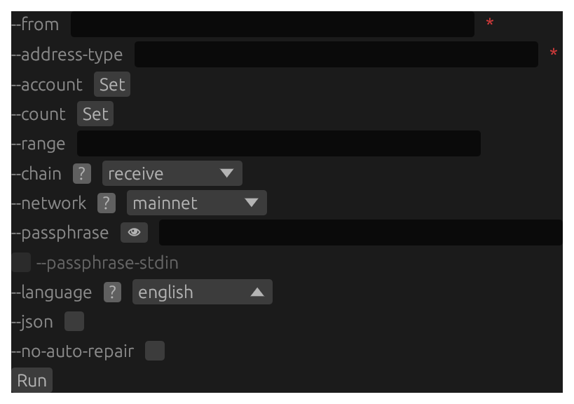

mnemonic addresses — GUI form screenshot (dark theme, 2x)

Structural render of the `mnemonic addresses` form — every flag and positional with its control kind and on-load default value (secret fields masked).

```
[ mnemonic > addresses ]
  --from              text  (required) -> <empty>
  --address-type      text  (required) -> <empty>
  --account           number  -> <unset>
  --count             number  -> <unset>
  --range             text  -> <empty>
  --chain             dropdown[receive,change,both]  -> receive
  --network           dropdown[mainnet,testnet,signet,regtest]  -> mainnet
  --passphrase        text  (secret) -> <masked> [reveal]
  --passphrase-stdin  checkbox  (secret) -> [ ] off [disabled]
  --language          dropdown[english,simplifiedchinese,traditionalchinese,czech,french,italian,japanese,korean,portuguese,spanish]  -> english
  --json              checkbox  -> [ ] off
  --no-auto-repair    checkbox  -> [ ] off
  [ Run ]
```

## `mnemonic build-descriptor`

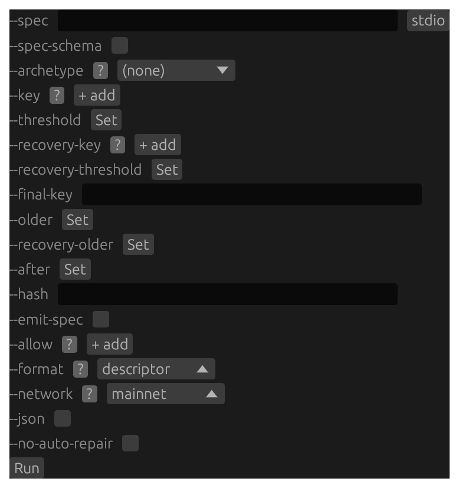

mnemonic build-descriptor — GUI form screenshot (dark theme, 2x)

Structural render of the `mnemonic build-descriptor` form — every flag and positional with its control kind and on-load default value (secret fields masked).

[output not shown]

## `mnemonic bundle`

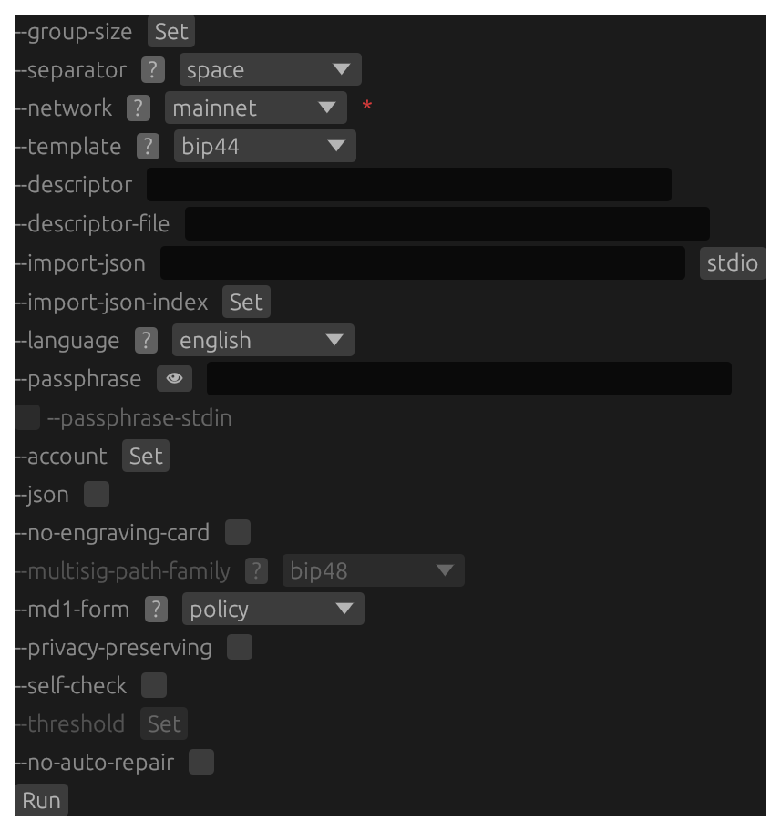

mnemonic bundle — GUI form screenshot (dark theme, 2x)

Structural render of the `mnemonic bundle` form — every flag and positional with its control kind and on-load default value (secret fields masked).

[output not shown]

## `mnemonic compare-cost`

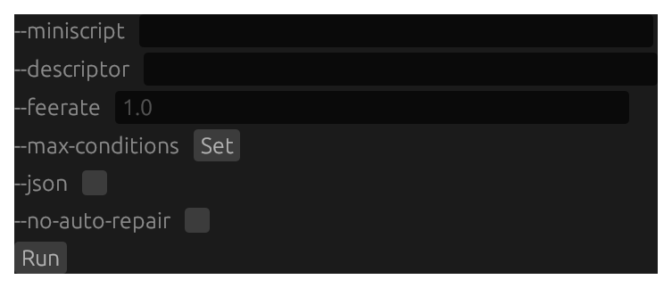

mnemonic compare-cost — GUI form screenshot (dark theme, 2x)

Structural render of the `mnemonic compare-cost` form — every flag and positional with its control kind and on-load default value (secret fields masked).

```
[ mnemonic > compare-cost ]
  --miniscript      text  -> <empty>
  --descriptor      text  -> <empty>
  --feerate         text  -> <hint:1.0>
  --max-conditions  number  -> <unset>
  --json            checkbox  -> [ ] off
  --no-auto-repair  checkbox  -> [ ] off
  [ Run ]
```

## `mnemonic convert`

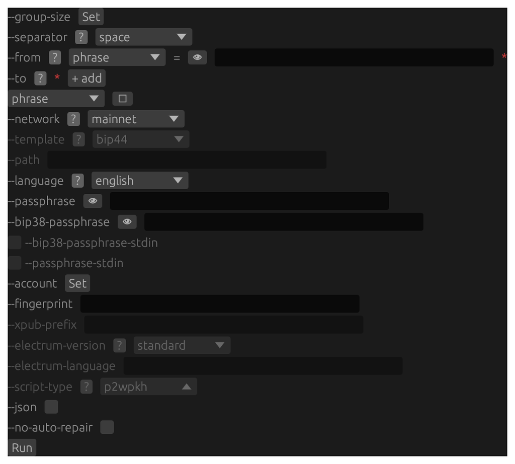

mnemonic convert — GUI form screenshot (dark theme, 2x)

Structural render of the `mnemonic convert` form — every flag and positional with its control kind and on-load default value (secret fields masked).

```
[ mnemonic > convert ]
  --group-size              number  -> <unset>
  --separator               dropdown[space,hyphen,comma]  -> space
  --from                    composite[phrase,seedqr,entropy,xpub,xprv,wif,fingerprint,path,ms1,mk1,bip38,minikey,electrum-phrase,address]  (required) -> phrase=<empty>
  --to                      dropdown[phrase,entropy,xpub,xprv,wif,fingerprint,path,ms1,mk1,bip38,minikey,electrum-phrase,address]  (required, repeating) -> phrase
  --network                 dropdown[mainnet,testnet,signet,regtest]  -> mainnet
  --template                dropdown[bip44,bip49,bip84,bip86,wsh-multi,wsh-sortedmulti,sh-wsh-multi,sh-wsh-sortedmulti,tr-multi-a,tr-sortedmulti-a]  -> bip44 [disabled]
  --path                    text  -> <empty> [disabled]
  --language                dropdown[english,simplifiedchinese,traditionalchinese,czech,french,italian,japanese,korean,portuguese,spanish]  -> english
  --passphrase              text  (secret) -> <masked> [reveal]
  --bip38-passphrase        text  (secret) -> <masked> [reveal]
  --bip38-passphrase-stdin  checkbox  (secret) -> [ ] off [disabled]
  --passphrase-stdin        checkbox  (secret) -> [ ] off [disabled]
  --account                 number  -> <unset>
  --fingerprint             text  -> <empty>
  --xpub-prefix             text  -> <empty> [disabled]
  --electrum-version        dropdown[standard,segwit]  -> standard [disabled]
  --electrum-language       text  -> <empty> [disabled]
  --script-type             dropdown[p2wpkh,p2sh-p2wpkh,p2tr]  -> p2wpkh [disabled]
  --json                    checkbox  -> [ ] off
  --no-auto-repair          checkbox  -> [ ] off
  [ Run ]
```

## `mnemonic decode-address`

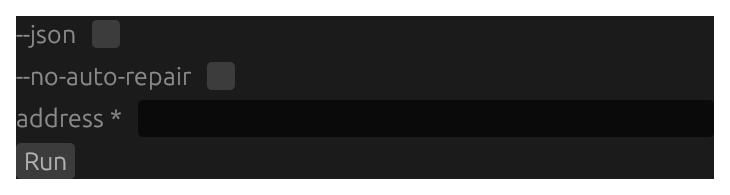

mnemonic decode-address — GUI form screenshot (dark theme, 2x)

Structural render of the `mnemonic decode-address` form — every flag and positional with its control kind and on-load default value (secret fields masked).

```
[ mnemonic > decode-address ]
  --json            checkbox  -> [ ] off
  --no-auto-repair  checkbox  -> [ ] off
  address           positional  (required) -> <empty>
  [ Run ]
```

## `mnemonic derive-child`

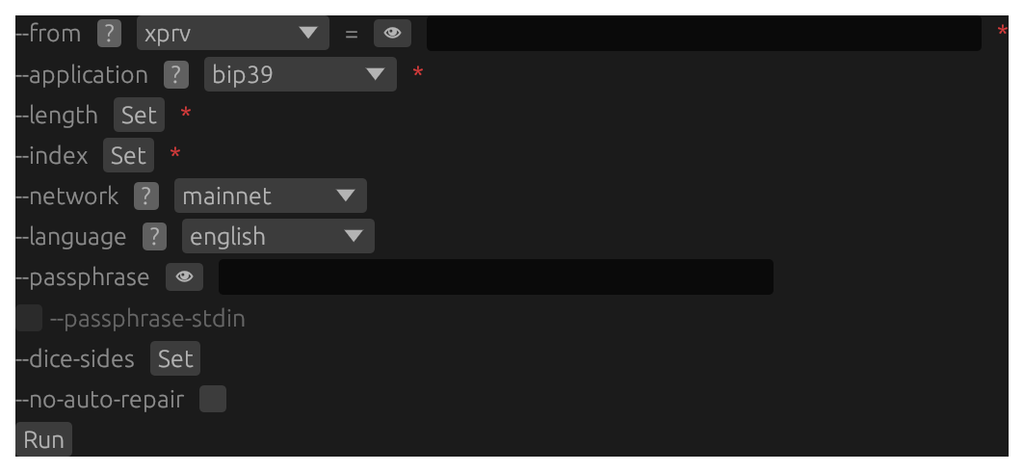

mnemonic derive-child — GUI form screenshot (dark theme, 2x)

Structural render of the `mnemonic derive-child` form — every flag and positional with its control kind and on-load default value (secret fields masked).

```
[ mnemonic > derive-child ]
  --from              composite[xprv,phrase]  (required) -> xprv=<empty>
  --application       dropdown[bip39,hd-seed,xprv,hex,password-base64,password-base85,dice,rsa,rsa-gpg]  (required) -> bip39
  --length            number  (required) -> <unset>
  --index             number  (required) -> <unset>
  --network           dropdown[mainnet,testnet,signet,regtest]  -> mainnet
  --language          dropdown[english,simplifiedchinese,traditionalchinese,czech,french,italian,japanese,korean,portuguese,spanish]  -> english
  --passphrase        text  (secret) -> <masked> [reveal]
  --passphrase-stdin  checkbox  (secret) -> [ ] off [disabled]
  --dice-sides        number  -> <unset>
  --no-auto-repair    checkbox  -> [ ] off
  [ Run ]
```

## `mnemonic electrum-decrypt`

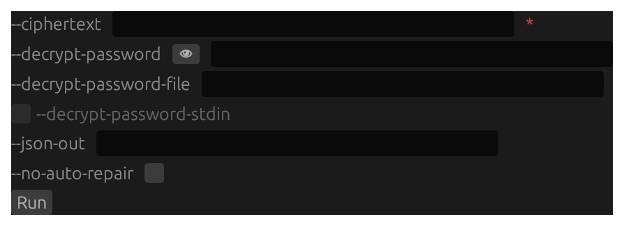

mnemonic electrum-decrypt — GUI form screenshot (dark theme, 2x)

Structural render of the `mnemonic electrum-decrypt` form — every flag and positional with its control kind and on-load default value (secret fields masked).

```
[ mnemonic > electrum-decrypt ]
  --ciphertext              text  (required) -> <empty>
  --decrypt-password        text  (secret) -> <masked> [reveal]
  --decrypt-password-file   path  -> <empty>
  --decrypt-password-stdin  checkbox  (secret) -> [ ] off [disabled]
  --json-out                path  -> <empty>
  --no-auto-repair          checkbox  -> [ ] off
  [ Run ]
```

## `mnemonic export-wallet`

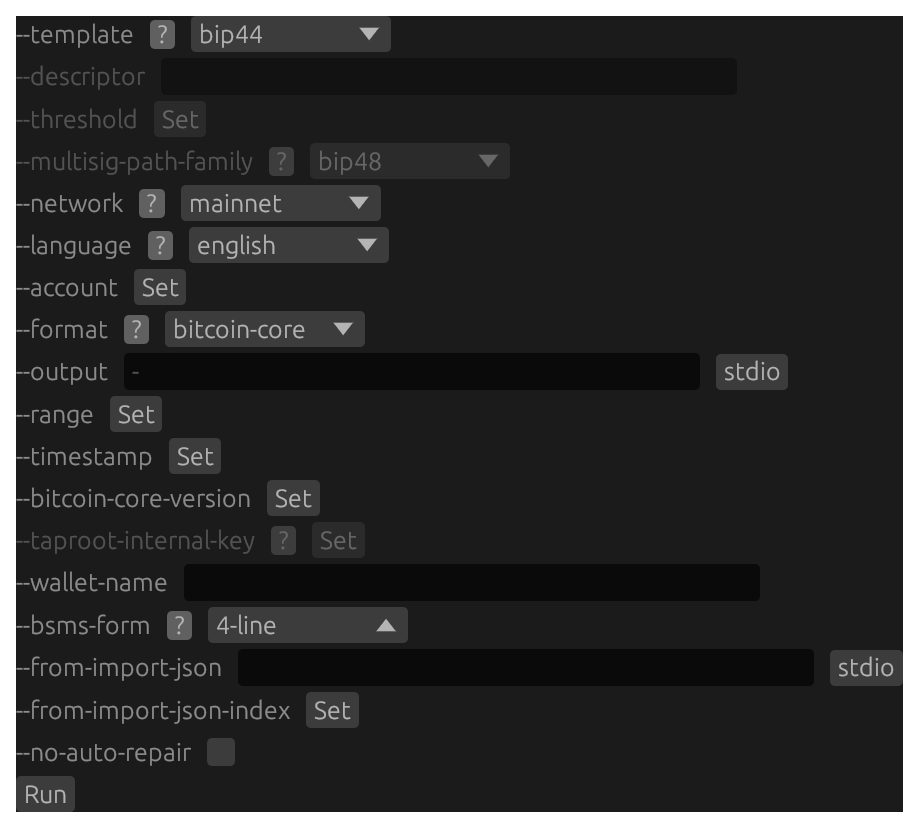

mnemonic export-wallet — GUI form screenshot (dark theme, 2x)

Structural render of the `mnemonic export-wallet` form — every flag and positional with its control kind and on-load default value (secret fields masked).

```
[ mnemonic > export-wallet ]
  --template                dropdown[bip44,bip49,bip84,bip86,wsh-multi,wsh-sortedmulti,sh-wsh-multi,sh-wsh-sortedmulti,tr-multi-a,tr-sortedmulti-a,(none)]  -> bip44
  --descriptor              text  -> <empty> [disabled]
  --threshold               number  -> <unset> [disabled]
  --multisig-path-family    dropdown[bip48,bip87]  -> bip48 [disabled]
  --network                 dropdown[mainnet,testnet,signet,regtest]  -> mainnet
  --language                dropdown[english,simplifiedchinese,traditionalchinese,czech,french,italian,japanese,korean,portuguese,spanish]  -> english
  --account                 number  -> <unset>
  --format                  dropdown[bitcoin-core,bip388,coldcard,coldcard-multisig,jade,sparrow,specter,electrum,green,bsms,descriptor]  -> bitcoin-core
  --output                  path(stdio)  -> <hint:->
  --range                   range  -> <unset>
  --timestamp               timestamp  -> <unset>
  --bitcoin-core-version    number  -> <unset>
  --taproot-internal-key    tagged-or-indexed[nums]  -> <unset> [disabled]
  --wallet-name             text  -> <empty>
  --bsms-form               dropdown[2-line,4-line]  -> 4-line
  --from-import-json        path(stdio)  -> <empty>
  --from-import-json-index  number  -> <unset>
  --no-auto-repair          checkbox  -> [ ] off
  [ slot editor: 0 rows ]
  [ Run ]
```

## `mnemonic final-word`

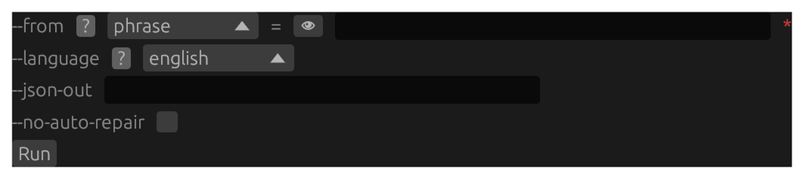

mnemonic final-word — GUI form screenshot (dark theme, 2x)

Structural render of the `mnemonic final-word` form — every flag and positional with its control kind and on-load default value (secret fields masked).

```
[ mnemonic > final-word ]
  --from            composite[phrase]  (required) -> phrase=<empty>
  --language        dropdown[english,simplifiedchinese,traditionalchinese,czech,french,italian,japanese,korean,portuguese,spanish]  -> english
  --json-out        path  -> <empty>
  --no-auto-repair  checkbox  -> [ ] off
  [ Run ]
```